## Homework 3

*Enter your name and EID here*

**This homework is due on Feb. 9, 2016 at 11:59pm. Please submit as a PDF file on Canvas.**

In this homework, you are asked to evaluate two data sets and determine if they are tidy data sets. *We are referring to a very specific definition of “tidy”, so if this term is unfamiliar to you, please review the lecture materials*.

**Question 1: (4 pts)** *The dataset `VADeaths` built into R lists death rates per 1000 people in Virginia in 1940. You can run `?VADeaths` to learn more about this data set.*

```r
VADeaths
```

```
##       Rural Male Rural Female Urban Male Urban Female
## 50-54       11.7          8.7       15.4          8.4
## 55-59       18.1         11.7       24.3         13.6
## 60-64       26.9         20.3       37.0         19.3
## 65-69       41.0         30.9       54.6         35.1
## 70-74       66.0         54.3       71.1         50.0
```

*Using the formal definition of tidy data that we learned in lecture, is this data set tidy? Explain why or why not.*

The data set is not tidy. There should be one column for sex (male or female), location (rural or urban), age group, and death rate. Instead, the data are arranged such that age groups vary along the rows and sex and location vary along the columns. Death rate varies along both the rows and the columns.

*The data set `InsectSprays` built into R contains counts of insects (in agricultural units) after treatment with different types of insecticides. You should be familiar with this data set from Homework 1. You can run `?InsectSprays` to learn more about this data set.*

```r
head(InsectSprays)
```

```
##   count spray
## 1    10     A
## 2     7     A
## 3    20     A
## 4    14     A
## 5    14     A
## 6    12     A
```

*Using the formal definition of tidy data that we learned in lecture, is this data set tidy? Explain why or why not.*

The dataset is tidy because each column is a variable (count and spray), and each row is an observation.

**Question 2: (2 pts)** *The `gapminder` dataset from the “gapminder”" package contains information about life expectancy, GDP per capita, and population by country from 1952 to 2007. **NOTE:** You will have to install the ‘gapminder’ package using the command `install.packages("gapminder")` before you can load the `gapminder` dataset.*

```r
library(gapminder)
head(gapminder)
```

```
## Source: local data frame [6 x 6]
##
##       country continent  year lifeExp      pop gdpPercap
##        (fctr)    (fctr) (int)   (dbl)    (int)     (dbl)
## 1 Afghanistan      Asia  1952  28.801  8425333  779.4453
## 2 Afghanistan      Asia  1957  30.332  9240934  820.8530
## 3 Afghanistan      Asia  1962  31.997 10267083  853.1007
## 4 Afghanistan      Asia  1967  34.020 11537966  836.1971
## 5 Afghanistan      Asia  1972  36.088 13079460  739.9811
## 6 Afghanistan      Asia  1977  38.438 14880372  786.1134
```

*Pick a continent and a year of your choosing. What is the **median** life expectancy for people living on that continent in the year that you chose? State your answer in a sentence. **NOTE:** The `gapminder` data set contains life expectancy data in 5 year increments beginning in 1952. Also, do not worry about the fact that you are computing a median of medians and not the true median life expectancy for the whole continent.*

I choose Africa in 1972.

```r
gapminder %>%
  filter(continent == 'Africa', year == '1972') %>%
  summarize(lifeExp = median(lifeExp))
```

```
## Source: local data frame [1 x 1]
##
##   lifeExp
##     (dbl)
## 1 47.0315
```

The median life expectancy of someone living in Africa in 1972 is 47 years.

**Question 3: (4 pts)** *Which countries have the largest difference between the highest and lowest reported life expectancies between **1988 and 2007**? List at least the top 5 and state your answer in a sentence. **HINT:** Use the functions `max()` and `min()` to determine the difference in life expectancy.*

```r
gapminder %>%
  filter(year >= 1988, year <= 2007) %>%
  group_by(country) %>%
  summarize(delta_lifeExp = max(lifeExp) - min(lifeExp)) %>%
  arrange(desc(delta_lifeExp)) %>%
  head()
```

```
## Source: local data frame [6 x 2]
##
##        country delta_lifeExp
##         (fctr)         (dbl)
## 1       Rwanda        22.643
## 2     Zimbabwe        20.388
## 3    Swaziland        18.861
## 4      Lesotho        17.093
## 5     Botswana        16.111
## 6 South Africa        12.549
```

The top 5 countries with the largest change in life expectancy between 1988 and 2007 are Rwanda, Zimbabwe, Swaziland, Lesotho, and Botswana.

*Choose a country from your list above and create a line plot of the life expectancy over time between **1952 and 2007**.*

I choose Zimbabwe.

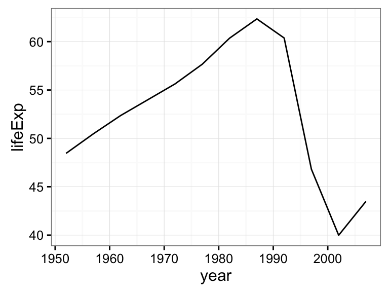

```r
gapminder %>%
  filter(country == "Zimbabwe") -> gapminder_new

ggplot(gapminder_new, aes(x=year, y=lifeExp)) + geom_line()
```